# Treatment Effect

Jeremy Binagia and Sai Gourisankar

7/5/2019

## Setup

```r
#library(dplyr)
library(ggplot2)
library(hexbin)
library(RColorBrewer)
library(ggrepel)
library(extrafont)
library(ggfortify)
library(ggsci)
#library(forecast)
#library(zoo)
library(extrafont)
#font_import()
#loadfonts(device = "win")
```

The first thing to explore is looking at the effect of the drug treatment on the total PANSS score over time.

```r
A_df=read.csv("Data/Study_A.csv")
B_df=read.csv("Data/Study_B.csv")
C_df=read.csv("Data/Study_C.csv")
D_df=read.csv("Data/Study_D.csv")
E_df=read.csv("Data/Study_E.csv")

summary(E_df)
```

```
##  Study      Country       PatientID         SiteID          RaterID
##  E:1962   Russia: 933   Min.   :50001   Min.   :100001   Min.   :150001
##           UK    :  20   1st Qu.:50124   1st Qu.:100015   1st Qu.:150034
##           USA   :1009   Median :50256   Median :100026   Median :150070
##                         Mean   :50255   Mean   :100029   Mean   :150069
##                         3rd Qu.:50382   3rd Qu.:100041   3rd Qu.:150096
##                         Max.   :50513   Max.   :100061   Max.   :150139
##   AssessmentiD         TxGroup        VisitDay            P1
##  Min.   :500001   Control  :1006   Min.   :  0.00   Min.   :1.000
##  1st Qu.:500595   Treatment: 956   1st Qu.:  0.00   1st Qu.:1.000
##  Median :501180                    Median : 42.00   Median :2.000
##  Mean   :501178                    Mean   : 63.97   Mean   :2.306
##  3rd Qu.:501756                    3rd Qu.:113.00   3rd Qu.:3.000
##  Max.   :502370                    Max.   :456.00   Max.   :6.000
##        P2              P3              P4              P5
##  Min.   :1.000   Min.   :1.000   Min.   :1.000   Min.   :1.000
##  1st Qu.:2.000   1st Qu.:1.000   1st Qu.:1.000   1st Qu.:1.000
##  Median :3.000   Median :1.000   Median :1.000   Median :1.000
##  Mean   :2.403   Mean   :2.047   Mean   :1.435   Mean   :1.633
##  3rd Qu.:3.000   3rd Qu.:3.000   3rd Qu.:2.000   3rd Qu.:2.000
##  Max.   :5.000   Max.   :5.000   Max.   :5.000   Max.   :6.000
##        P6              P7              N1              N2
##  Min.   :1.000   Min.   :1.000   Min.   :1.000   Min.   :1.000
##  1st Qu.:2.000   1st Qu.:1.000   1st Qu.:3.000   1st Qu.:3.000
##  Median :3.000   Median :1.000   Median :3.000   Median :3.000
##  Mean   :2.486   Mean   :1.377   Mean   :3.146   Mean   :3.065
##  3rd Qu.:3.000   3rd Qu.:2.000   3rd Qu.:4.000   3rd Qu.:4.000
##  Max.   :5.000   Max.   :5.000   Max.   :6.000   Max.   :6.000
##        N3              N4              N5              N6
##  Min.   :1.000   Min.   :1.000   Min.   :1.000   Min.   :1.000
##  1st Qu.:1.000   1st Qu.:2.000   1st Qu.:3.000   1st Qu.:1.000
##  Median :2.000   Median :3.000   Median :3.000   Median :3.000
##  Mean   :2.384   Mean   :3.031   Mean   :3.262   Mean   :2.407
##  3rd Qu.:3.000   3rd Qu.:4.000   3rd Qu.:4.000   3rd Qu.:3.000
##  Max.   :6.000   Max.   :6.000   Max.   :6.000   Max.   :6.000
##        N7              G1              G2             G3
##  Min.   :1.000   Min.   :1.000   Min.   :1.00   Min.   :1.000
##  1st Qu.:1.000   1st Qu.:1.000   1st Qu.:1.00   1st Qu.:1.000
##  Median :2.000   Median :1.000   Median :2.00   Median :1.000
##  Mean   :2.222   Mean   :1.746   Mean   :1.94   Mean   :1.369
```

[output cut: 15 more lines]

```
##  Max.   :5.000   Max.   :5.000   Max.   :4.000   Max.   :5.000
##       G12            G13             G14             G15
##  Min.   :1.00   Min.   :1.000   Min.   :1.000   Min.   :1.000
##  1st Qu.:2.00   1st Qu.:1.000   1st Qu.:1.000   1st Qu.:1.000
##  Median :3.00   Median :2.000   Median :1.000   Median :2.000
##  Mean   :2.78   Mean   :2.347   Mean   :1.403   Mean   :1.929
##  3rd Qu.:4.00   3rd Qu.:3.000   3rd Qu.:2.000   3rd Qu.:3.000
##  Max.   :5.00   Max.   :5.000   Max.   :4.000   Max.   :4.000
##       G16         PANSS_Total
##  Min.   :1.000   Min.   :31.00
##  1st Qu.:1.000   1st Qu.:55.00
##  Median :3.000   Median :64.00
##  Mean   :2.374   Mean   :63.64
##  3rd Qu.:3.000   3rd Qu.:72.00
##  Max.   :6.000   Max.   :99.00
```

Note that study E does not contain the `LeadStatus` column so we remove it from the other studies before combining the various dataframes.

```r
#remove LeadStatus column
A_sub = A_df[ , -which(names(A_df) %in% c("LeadStatus"))]
B_sub = B_df[ , -which(names(B_df) %in% c("LeadStatus"))]
C_sub = C_df[ , -which(names(C_df) %in% c("LeadStatus"))]
D_sub = D_df[ , -which(names(D_df) %in% c("LeadStatus"))]
E_sub = E_df # study E does not have the LeadStatus column!

combined_df = rbind(A_sub,B_sub,C_sub,D_sub,E_sub) # combine datasets
combined_df$totalP=rowSums(combined_df[,c("P1","P2","P3","P4","P5","P6","P7")])
combined_df$totalN=rowSums(combined_df[,c("N1","N2","N3","N4","N5","N6","N7")])
combined_df$totalG=rowSums(combined_df[,c("G1","G2","G3","G4","G5","G6","G7","G8","G9","G10","G11","G12","G13","G14","G15","G16")])
```

## Visual inspection of treatment vs. control

### Total PANSS scores

We will first plot `PANSS_Total` vs `VisitDay`, for the `Treatment` and `Control` groups.

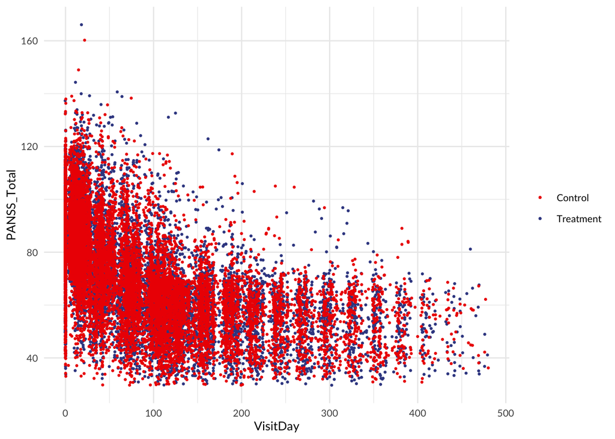

```r
combined_df_treated=combined_df[which(combined_df$TxGroup == "Treatment"),]
combined_df_control=combined_df[which(combined_df$TxGroup == "Control"),]

# considered looking at a moving average
# moving_average_day=30
# combined_df_treated$roll=rollmean(combined_df_treated$PANSS_Total,moving_average_day,na.pad=TRUE)
# combined_df_control$roll=rollmean(combined_df_control$PANSS_Total,moving_average_day,na.pad=TRUE)

p = ggplot(NULL,aes())+
  geom_jitter(data=combined_df_treated,aes(x=VisitDay,y=PANSS_Total,col="Treatment"),size=0.5)+
  geom_jitter(data=combined_df_control,aes(x=VisitDay,y=PANSS_Total,col="Control"),size=0.5)+
  scale_color_manual(values=rev(pal_aaas("default")(2)))+
  #geom_line(data=combined_df_treated,aes(x=VisitDay,y=roll,col="Treatment"))+
  #geom_line(data=combined_df_control,aes(x=VisitDay,y=roll,col="Control"))+
  theme_minimal()+
  theme(legend.title=element_blank(),plot.title=element_text(hjust=0.5,size=10,family="Lato"),plot.subtitle=element_text(hjust=0.5,size=8,family="Lato"),text=element_text(size=10,family="Lato"))
# ggsave("Figures/panss_total_vs_visit_day",p,device = "pdf",width=6,height=6,units="in",dpi="retina")
ggsave("Figures/panss_total_vs_visit_day.png",width=6,height=4,units="in",device="png",dpi="retina")
```

A plot of the total PANSS score over time does not seem to suggest a treatment effect. But to quantify this we can do a linear regression on the total PANSS score vs time, where we regress PANSS_Total onto VisitDay, and a dummy variable for Control or Treatment interacting with VisitDay: $y=\beta_0 + \beta_1*VisitDay + \beta_2*VisitDay*Treatment$

### Individual PANSS scores

Instead of looking at combined scores scores, we can look at individual positive and negative scores to see if any visually appear to show a trend with respect to treatment group.

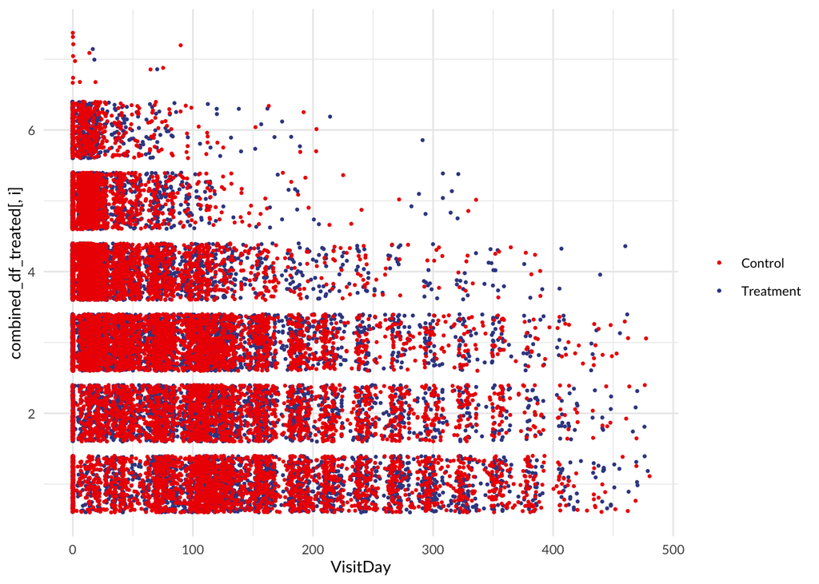

```r
#Plot given PANSS score vs Visit Day, for patients and control
combined_df_treated=combined_df[which(combined_df$TxGroup == "Treatment"),]
combined_df_control=combined_df[which(combined_df$TxGroup == "Control"),]

i = 9 # to prevent an overabundance of output in the html/pdf document
#for (i in 9:38) {
p = ggplot(NULL,aes())+
  geom_jitter(data=combined_df_treated,aes(x=VisitDay,y=combined_df_treated[,i],col="Treatment"),size=0.5)+
  geom_jitter(data=combined_df_control,aes(x=VisitDay,y=combined_df_control[,i],col="Control"),size=0.5)+
  scale_color_manual(values=rev(pal_aaas("default")(2)))+
  theme_minimal()+
  theme(legend.title=element_blank(),plot.title=element_text(hjust=0.5,size=10,family="Lato"),plot.subtitle=element_text(hjust=0.5,size=8,family="Lato"),text=element_text(size=10,family="Lato"))
print(p)
```

```r
#}
```

Again do not see an appreciable difference between control and treatment.

### Total scores for each category

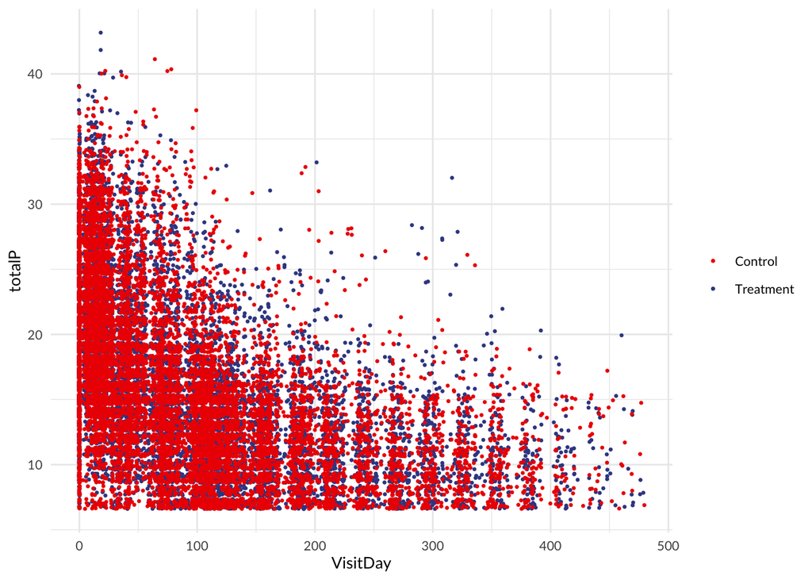

```r
#Plot total for each category vs Visit Day, for patients and control
combined_df_treated=combined_df[which(combined_df$TxGroup == "Treatment"),]
combined_df_control=combined_df[which(combined_df$TxGroup == "Control"),]

p = ggplot(NULL,aes())+
  geom_jitter(data=combined_df_treated,aes(x=VisitDay,y=totalP,col="Treatment"),size=0.5)+
  geom_jitter(data=combined_df_control,aes(x=VisitDay,y=totalP,col="Control"),size=0.5)+
  scale_color_manual(values=rev(pal_aaas("default")(2)))+
  theme_minimal()+
  theme(legend.title=element_blank(),plot.title=element_text(hjust=0.5,size=10,family="Lato"),plot.subtitle=element_text(hjust=0.5,size=8,family="Lato"),text=element_text(size=10,family="Lato"))
print(p)
```

### Total PANSS for a given study

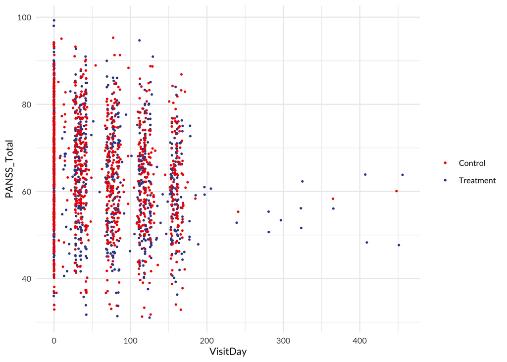

```r
study = E_sub

treated = study[which(study$TxGroup == "Treatment"),]
control = study[which(study$TxGroup == "Control"),]

p = ggplot(NULL,aes())+
  geom_jitter(data=treated,aes(x=VisitDay,y=PANSS_Total,col="Treatment"),size=0.5)+
  geom_jitter(data=control,aes(x=VisitDay,y=PANSS_Total,col="Control"),size=0.5)+
  scale_color_manual(values=rev(pal_aaas("default")(2)))+
  theme_minimal()+
  theme(legend.title=element_blank(),plot.title=element_text(hjust=0.5,size=10,family="Lato"),plot.subtitle=element_text(hjust=0.5,size=8,family="Lato"),text=element_text(size=10,family="Lato"))
print(p)
```

No individual study appears to show an effect of treatment.

## Regression of total PANSS

```r
#attach(combined_df)
lm.fit=lm(PANSS_Total~VisitDay+VisitDay:TxGroup, data=combined_df)
contrasts(combined_df$TxGroup) # display encoding for treatment
```

```
##           Treatment
## Control           0
## Treatment         1
```

The dummy encoding is 1 for treatment, 0 for Control.

```r
summary(lm.fit)
```

```
##
## Call:
## lm(formula = PANSS_Total ~ VisitDay + VisitDay:TxGroup, data = combined_df)
##
## Residuals:
##     Min      1Q  Median      3Q     Max
## -48.651  -9.661  -0.778   9.440  86.460
##
## Coefficients:
##                             Estimate Std. Error t value Pr(>|t|)
## (Intercept)               81.6507988  0.1421231 574.508   <2e-16 ***
## VisitDay                  -0.1170455  0.0013550 -86.380   <2e-16 ***
## VisitDay:TxGroupTreatment -0.0002127  0.0015790  -0.135    0.893
## ---
## Signif. codes:  0 '***' 0.001 '**' 0.01 '*' 0.05 '.' 0.1 ' ' 1
##
## Residual standard error: 15.46 on 22906 degrees of freedom
## Multiple R-squared:  0.3317, Adjusted R-squared:  0.3317
## F-statistic:  5685 on 2 and 22906 DF,  p-value: < 2.2e-16
```

From the linear regression, we cannot rule out the hypothesis that the treatment group (Control or Treated) had no effect on the total PANSS score over time.

### Regression for total category scores

We still cannot rule out that there is no effect of treatment on the patient group’s change in total PANSS score. Perhaps we can compare just the total positive symptoms of the patient, the total negative symptoms of the patient, and the total general psychopathology symptoms of the patient, to see if there is an effect on those scores.

```r
combined_df$totalP=rowSums(combined_df[,c("P1","P2","P3","P4","P5","P6","P7")])
combined_df$totalN=rowSums(combined_df[,c("N1","N2","N3","N4","N5","N6","N7")])
combined_df$totalG=rowSums(combined_df[,c("G1","G2","G3","G4","G5","G6","G7","G8","G9","G10","G11","G12","G13","G14","G15","G16")])
#attach(combined_df)
lm.fit.p=lm(totalP~VisitDay+VisitDay:TxGroup, data=combined_df)
lm.fit.n=lm(totalN~VisitDay+VisitDay:TxGroup, data=combined_df)
lm.fit.g=lm(totalG~VisitDay+VisitDay:TxGroup, data=combined_df)
```

```r
summary(lm.fit.p)
```

```
##
## Call:
## lm(formula = totalP ~ VisitDay + VisitDay:TxGroup, data = combined_df)
##
## Residuals:
##      Min       1Q   Median       3Q      Max
## -12.7352  -3.8852  -0.6634   3.2648  24.0386
##
## Coefficients:
##                             Estimate Std. Error t value Pr(>|t|)
## (Intercept)               19.7352229  0.0503472 391.982   <2e-16 ***
## VisitDay                  -0.0369592  0.0004800 -76.996   <2e-16 ***
## VisitDay:TxGroupTreatment -0.0002998  0.0005594  -0.536    0.592
## ---
## Signif. codes:  0 '***' 0.001 '**' 0.01 '*' 0.05 '.' 0.1 ' ' 1
##
## Residual standard error: 5.476 on 22906 degrees of freedom
## Multiple R-squared:  0.2841, Adjusted R-squared:  0.2841
## F-statistic:  4546 on 2 and 22906 DF,  p-value: < 2.2e-16
```

```r
summary(lm.fit.n)
```

```
##
## Call:
## lm(formula = totalN ~ VisitDay + VisitDay:TxGroup, data = combined_df)
##
## Residuals:
##      Min       1Q   Median       3Q      Max
## -15.0112  -3.4030  -0.0781   3.2281  24.5152
##
## Coefficients:
##                             Estimate Std. Error t value Pr(>|t|)
## (Intercept)               22.0111724  0.0464175 474.200   <2e-16 ***
## VisitDay                  -0.0239254  0.0004425 -54.063   <2e-16 ***
## VisitDay:TxGroupTreatment -0.0002245  0.0005157  -0.435    0.663
## ---
## Signif. codes:  0 '***' 0.001 '**' 0.01 '*' 0.05 '.' 0.1 ' ' 1
##
## Residual standard error: 5.049 on 22906 degrees of freedom
## Multiple R-squared:  0.1638, Adjusted R-squared:  0.1638
## F-statistic:  2244 on 2 and 22906 DF,  p-value: < 2.2e-16
```

```r
summary(lm.fit.g)
```

```
##
## Call:
## lm(formula = totalG ~ VisitDay + VisitDay:TxGroup, data = combined_df)
##
## Residuals:
##     Min      1Q  Median      3Q     Max
## -23.904  -5.330  -0.405   4.933  44.101
##
## Coefficients:
##                             Estimate Std. Error t value Pr(>|t|)
## (Intercept)               39.9044036  0.0740077 539.193   <2e-16 ***
## VisitDay                  -0.0561609  0.0007056 -79.594   <2e-16 ***
## VisitDay:TxGroupTreatment  0.0003116  0.0008223   0.379    0.705
## ---
## Signif. codes:  0 '***' 0.001 '**' 0.01 '*' 0.05 '.' 0.1 ' ' 1
##
## Residual standard error: 8.05 on 22906 degrees of freedom
## Multiple R-squared:  0.295,  Adjusted R-squared:  0.2949
## F-statistic:  4791 on 2 and 22906 DF,  p-value: < 2.2e-16
```

Individually, it does not look like there was a statistically significant effect of treatment on the total positive, negative, or general pathophysiology scores.